# Analytics Edge: Unit 4 - Keeping An Eye on Healthcare Costs

Sulman Khan

October 26, 2018

## The D2Hawkeye Story

### D2Hawkeye

- Founded by Chris Kryder, MD, MBA in 2001
- Combine expert knowledge and databases with analytics to improve quality and cost management in healthcare
- Located in Massachusetts USA, grew very fast and was sold to Verisk Analytics in 2009

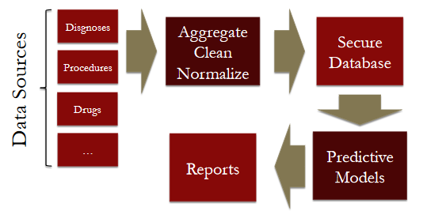

### Healthcare Case Management

- D2Hawkeye tries to improve healthcare case management
  - Identify high-risk patients
  - Work with patients to manage treatment and associated costs
  - Arrange specialist care
- Medical costs often relate to severity of health problems, and are an issue for both patient and provider
- Goal: improve the quality of cost predictions

### Impact

- Many different types of clients
  - Third party administrators of medical claims
  - Case management companies
  - Benefit consultants
  - Health plans
- **Millions of people** analyzed monthly through analytic platform in 2009
- **Thousands of employers** processed monthly

### Pre-Analytics Approach

- Human judgement - MDs manually analyzed patient histories and developed
- Limited data sets
- Costly and inefficient
- Can we used analytics instead?

### Data Sources

- Healthcare industry is data-rich, but data may be hard to access
  - Unstructured - doctor’s notes
  - Unavailable - hard to get due to differences in technology
  - Inaccessible - strong privacy laws around healthcare data sharing
- What is available?
- Claims data
  - Requests for reimbursement submitted to insurance companies or state-provided insurance from doctors, hospitals, and pharmacies.
- Eligibility information
- Demographic information

### Claims Data

- Rich, structured data source
- Very high dimension
- Doesn’t capture all aspects of a persons treatment or health - many things must be inferred
- Unlike electronic medical records, we do not know the results of a test, only that a test was administered

### D2Hawkeye’s Claims Data

- Available: claims data for **2.4 million people** over a span of **3 years**
- Include only people with data for at least 10 months in both periods - **400,000 people**

### Variables / Cost Profiles

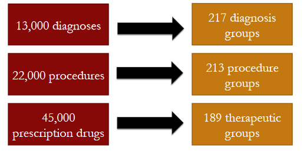

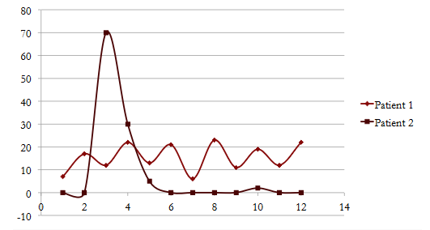

- Variables
  - Chronic condition cost indicators
  - Gender and age

### Cost Variables

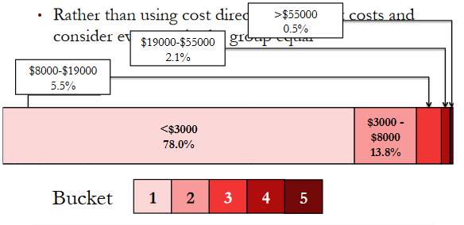

### Medical Intepretation of Buckets

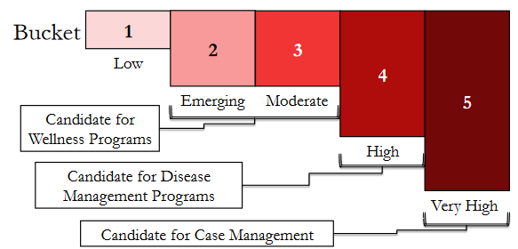

### Error Measures

- Typically we use R<sup>2</sup> or accuracy, but others can be used
- In case of D2Hawkeye, failing to classify a **high-cost patient** is worse than failing to classify a **low-cost patient** correctly
- Use a “penalty error” to capture this asymmetry

### Penalty Error

- Key idea: use asymmetric penalties
- Define a “penalty matrix” as the cost of being wrong

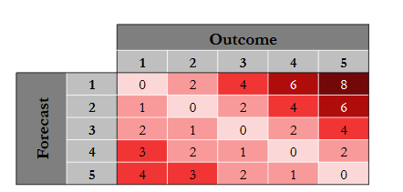

### Baseline

- Baseline is to simply predict that the cost in the next “period” will be the cost in the current period
- Accuracy of 75%
- Penalty Error of 0.56

### Multi-class Classification

- We use predicting a bucket number

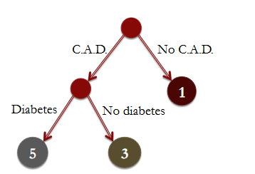

### Most Important Factors

- First splits are related to cost

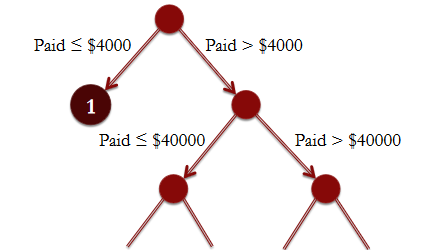

### Secondary Factors

- Risk factors
- Chronic Illness
- **“Q146”**
  - Asthma + depression
- **“Q1”**
  - Risk factor indicating hylan injection
  - Possible knee replacement or arthroscopy

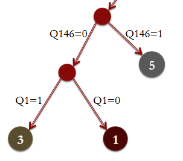

### Example Groups for Bucket 5

- Under 35 years old, between $3300 and $3900 in claims, C.A.D., but no office visits in last year.
- Claims between $3900 and $43,000 with at least $8000 paid in last 12 months, $4300 in pharmacy claims, acute cost profile and cancer diagnosis
- More than $58,000 in claims, at least $55,000 paid in last 12 months, and not an acute profile

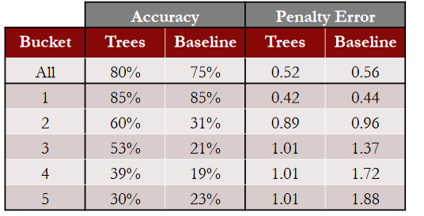

### Insights

- **Substantial improvement** over the baseline
- **Double accuracy** over baseline in some cases
- Smaller accuracy improvement on **bucket 5**, but **much lower penalty**

### Analytics Provide an Edge

- Substantial improvement in D2Hawkeye’s ability to identify patients who need more attention
- Because the model was interpret able, physicians were able to improve the model by identifying new variables and refining existing variables
- Analytics gave D2Hawkeye an edge over competition using “last century” methods

## The D2Hawkeye Story in R

### Read in the data

```r
# Read in the data
Claims = read.csv("ClaimsData.csv")
# Output structure
str(Claims)
```

```
## 'data.frame':    458005 obs. of  16 variables:
##  $ age              : int  85 59 67 52 67 68 75 70 67 67 ...
##  $ alzheimers       : int  0 0 0 0 0 0 0 0 0 0 ...
##  $ arthritis        : int  0 0 0 0 0 0 0 0 0 0 ...
##  $ cancer           : int  0 0 0 0 0 0 0 0 0 0 ...
##  $ copd             : int  0 0 0 0 0 0 0 0 0 0 ...
##  $ depression       : int  0 0 0 0 0 0 0 0 0 0 ...
##  $ diabetes         : int  0 0 0 0 0 0 0 0 0 0 ...
##  $ heart.failure    : int  0 0 0 0 0 0 0 0 0 0 ...
##  $ ihd              : int  0 0 0 0 0 0 0 0 0 0 ...
##  $ kidney           : int  0 0 0 0 0 0 0 0 0 0 ...
##  $ osteoporosis     : int  0 0 0 0 0 0 0 0 0 0 ...
##  $ stroke           : int  0 0 0 0 0 0 0 0 0 0 ...
##  $ reimbursement2008: int  0 0 0 0 0 0 0 0 0 0 ...
##  $ bucket2008       : int  1 1 1 1 1 1 1 1 1 1 ...
##  $ reimbursement2009: int  0 0 0 0 0 0 0 0 0 0 ...
##  $ bucket2009       : int  1 1 1 1 1 1 1 1 1 1 ...
```

### Split the data

```r
# Percentage of patients in each cost bucket
table(Claims$bucket2009)/nrow(Claims)
```

```
##
##           1           2           3           4           5
## 0.671267781 0.190170413 0.089466272 0.043324855 0.005770679
```

```r
# Split the data
library(caTools)

set.seed(88)

spl = sample.split(Claims$bucket2009, SplitRatio = 0.6)

ClaimsTrain = subset(Claims, spl==TRUE)

ClaimsTest = subset(Claims, spl==FALSE)
```

### Baseline Method

```r
# Baseline method
table(ClaimsTest$bucket2009, ClaimsTest$bucket2008)
```

```
##
##          1      2      3      4      5
##   1 110138   7787   3427   1452    174
##   2  16000  10721   4629   2931    559
##   3   7006   4629   2774   1621    360
##   4   2688   1943   1415   1539    352
##   5    293    191    160    309    104
```

```r
(110138 + 10721 + 2774 + 1539 + 104)/nrow(ClaimsTest)
```

```
## [1] 0.6838135
```

### Create Penalty Matrix

```r
# Penalty Matrix
PenaltyMatrix = matrix(c(0,1,2,3,4,2,0,1,2,3,4,2,0,1,2,6,4,2,0,1,8,6,4,2,0), byrow=TRUE, nrow=5)

PenaltyMatrix
```

```
##      [,1] [,2] [,3] [,4] [,5]
## [1,]    0    1    2    3    4
## [2,]    2    0    1    2    3
## [3,]    4    2    0    1    2
## [4,]    6    4    2    0    1
## [5,]    8    6    4    2    0
```

```r
# Penalty Error of Baseline Method
as.matrix(table(ClaimsTest$bucket2009, ClaimsTest$bucket2008))*PenaltyMatrix
```

```
##
##         1     2     3     4     5
##   1     0  7787  6854  4356   696
##   2 32000     0  4629  5862  1677
##   3 28024  9258     0  1621   720
##   4 16128  7772  2830     0   352
##   5  2344  1146   640   618     0
```

```r
sum(as.matrix(table(ClaimsTest$bucket2009, ClaimsTest$bucket2008))*PenaltyMatrix)/nrow(ClaimsTest)
```

```
## [1] 0.7386055
```

### CART Model

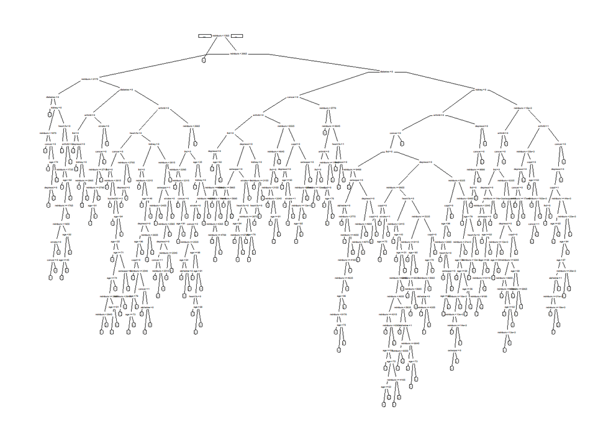

```r
# Load necessary libraries
library(rpart)
library(rpart.plot)

# CART model
ClaimsTree = rpart(bucket2009 ~ age + alzheimers + arthritis + cancer + copd + depression + diabetes + heart.failure + ihd + kidney + osteoporosis + stroke + bucket2008 + reimbursement2008, data=ClaimsTrain, method="class", cp=0.00005)
# Plot CART
prp(ClaimsTree)
```

```r
# Make predictions
PredictTest = predict(ClaimsTree, newdata = ClaimsTest, type = "class")

table(ClaimsTest$bucket2009, PredictTest)
```

```
##    PredictTest
##          1      2      3      4      5
##   1 114141   8610    124    103      0
##   2  18409  16102    187    142      0
##   3   8027   8146    118     99      0
##   4   3099   4584     53    201      0
##   5    351    657      4     45      0
```

```r
(114141 + 16102 + 118 + 201 + 0)/nrow(ClaimsTest)
```

```
## [1] 0.7126669
```

```r
# Penalty Error
as.matrix(table(ClaimsTest$bucket2009, PredictTest))*PenaltyMatrix
```

```
##    PredictTest
##         1     2     3     4     5
##   1     0  8610   248   309     0
##   2 36818     0   187   284     0
##   3 32108 16292     0    99     0
##   4 18594 18336   106     0     0
##   5  2808  3942    16    90     0
```

```r
sum(as.matrix(table(ClaimsTest$bucket2009, PredictTest))*PenaltyMatrix)/nrow(ClaimsTest)
```

```
## [1] 0.7578902
```

### CART model with loss matrix

```r
# New CART model with loss matrix
ClaimsTree = rpart(bucket2009 ~ age + alzheimers + arthritis + cancer + copd + depression + diabetes + heart.failure + ihd + kidney + osteoporosis + stroke + bucket2008 + reimbursement2008, data=ClaimsTrain, method="class", cp=0.00005, parms=list(loss=PenaltyMatrix))

# Redo predictions and penalty error
PredictTest = predict(ClaimsTree, newdata = ClaimsTest, type = "class")

table(ClaimsTest$bucket2009, PredictTest)
```

```
##    PredictTest
##         1     2     3     4     5
##   1 94310 25295  3087   286     0
##   2  7176 18942  8079   643     0
##   3  3590  7706  4692   401     1
##   4  1304  3193  2803   636     1
##   5   135   356   408   156     2
```

```r
(94310 + 18942 + 4692 + 636 + 2)/nrow(ClaimsTest)
```

```
## [1] 0.6472746
```

```r
sum(as.matrix(table(ClaimsTest$bucket2009, PredictTest))*PenaltyMatrix)/nrow(ClaimsTest)
```

```
## [1] 0.6418161
```